# Summary report for Scotch Street

UKMON

2017-07-18

# Summary of activity in 2017

Scotch Street operates 3 cameras.

In 2017 Scotch Street has recorded 301 individual meteor observations. These observations comprise 97 sporadic meteors and 204 stream meteors. A breakdown by month is shown below.

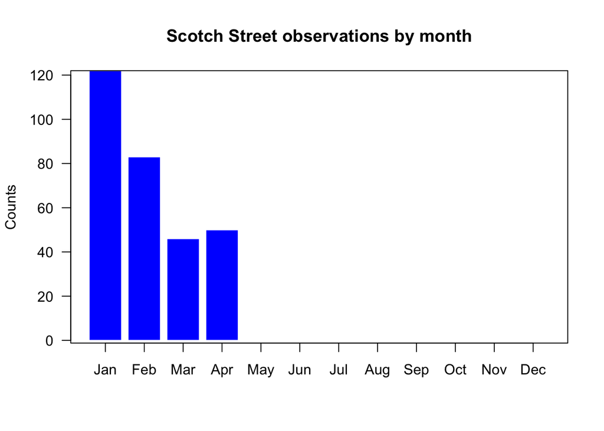

The following shows observation counts by stream for the 20 most frequent showers based on preliminary UFO ANALYSIS classifications:

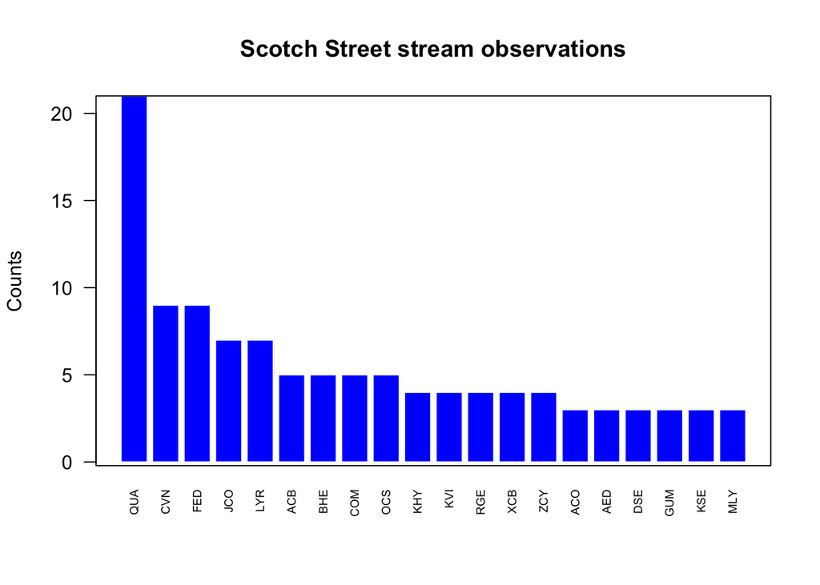

The following table shows which stations are generating matched observations with this station and the number of matches:

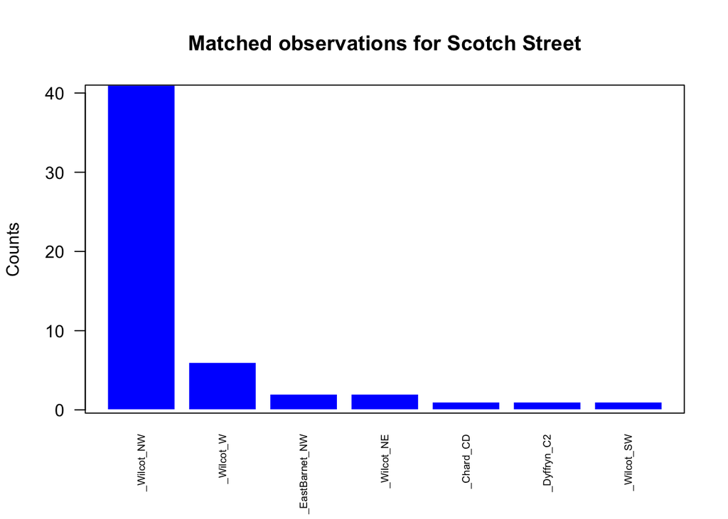

## Fireball activity

(Based on IAU definition of apparrent magnitude of -4.0 of greater)

| Datetime | Magnitude | Duration | Stream |
| --- | --- | --- | --- |
| 2017-04-23 01:54:45 | -4.5 | 0.48 | LYR |
| 2017-01-07 04:01:22 | -4.4 | 0.48 | SPO |
| 2017-03-24 00:06:21 | -4.3 | 0.78 | KVI |
| 2017-04-23 01:54:45 | -4.3 | 0.68 | LYR |
| 2017-01-23 22:41:49 | -4.1 | 0.44 | SPO |

# Observations recorded by Scotch Street, 2013 to 2017

UKMON data for Scotch Street covers the period from 2013 to 2017 and totals 7290 individual meteor observations. These observations comprise 1177 sporadic meteors and 6113 stream meteors.

This section provides a summary of all observations by Scotch Street from 2013 to 2017. A breakdown of the number of observations by year is given in the histogram below.

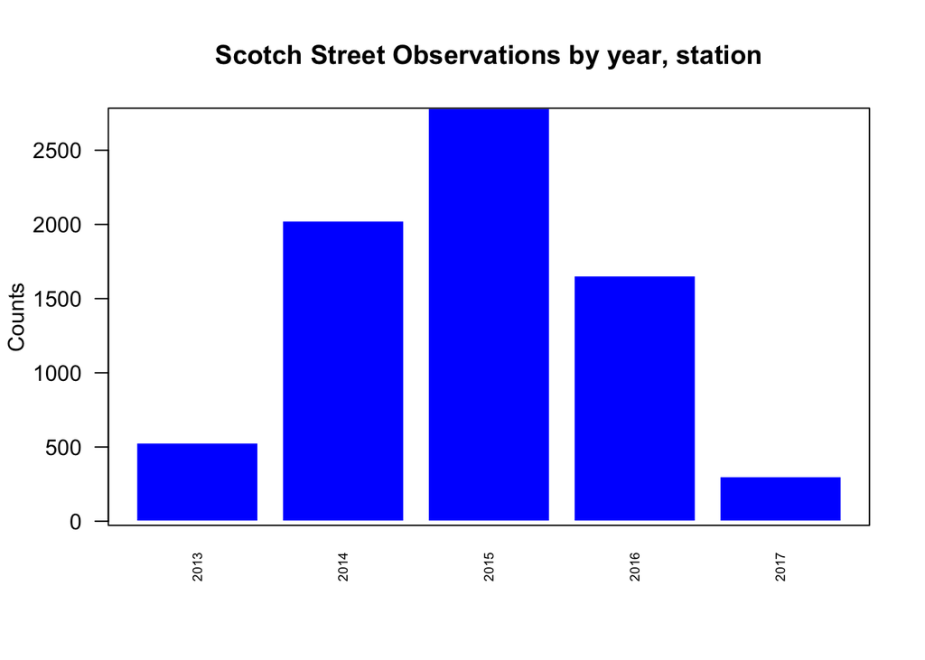

The following graph shows observation counts by stream (preliminary UFO ANALYSIS classification). A detailed breakdown by shower is given in the table at the end of this report.

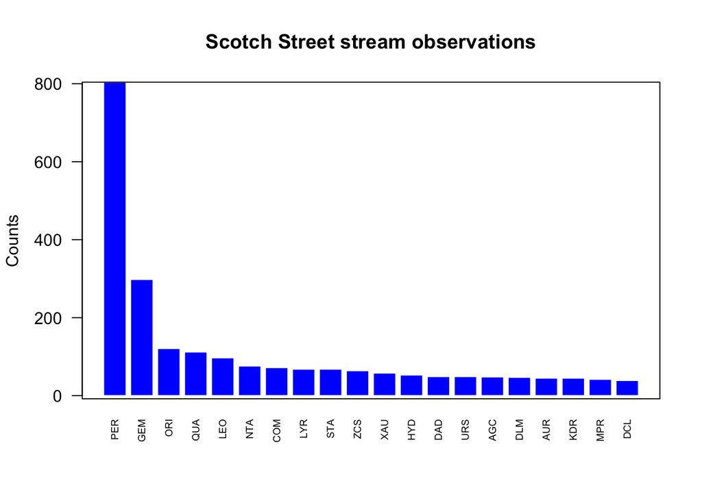

## Fireball activity

Fireballs recorded (Based on IAU definition of apparrent magnitude of -4.0 of greater)

| Datetime | Magnitude | Duration | Stream |
| --- | --- | --- | --- |
| 2016-07-25 22:35:05 | -9.8 | 0.34 | CAN |
| 2016-08-02 21:31:16 | -7.9 | 0.10 | TPR |
| 2016-09-21 21:58:50 | -7.2 | 0.64 | DAU |
| 2016-03-27 23:14:12 | -6.9 | 1.54 | SPO |
| 2015-10-02 02:31:26 | -6.8 | 0.78 | POR |
| 2015-12-09 06:42:25 | -6.8 | 0.28 | IAR |
| 2016-03-27 23:14:12 | -6.7 | 1.44 | SPO |
| 2013-12-08 01:35:45 | -5.9 | 0.80 | HYD |
| 2016-07-31 02:58:46 | -5.8 | 0.18 | ABA |
| 2014-08-17 02:59:43 | -5.7 | 0.24 | KCG |
| 2016-12-08 00:18:36 | -5.7 | 0.88 | NZT |
| 2014-04-20 00:16:35 | -5.6 | 1.96 | ABO |
| 2015-11-19 02:10:28 | -5.6 | 0.62 | LEO |
| 2016-07-25 22:35:05 | -5.4 | 0.74 | PER |
| 2015-10-14 23:32:33 | -5.2 | 0.84 | SPO |
| 2015-11-19 01:52:21 | -5.2 | 1.64 | LEO |
| 2016-11-12 23:55:08 | -5.1 | 0.18 | ORI |
| 2013-11-17 00:33:49 | -4.9 | 0.92 | NTA |
| 2016-08-11 23:31:04 | -4.9 | 0.84 | PER |
| 2013-11-21 03:03:49 | -4.8 | 0.54 | NLM |
| 2013-11-21 18:54:00 | -4.8 | 0.72 | OKD |
| 2014-01-10 21:52:45 | -4.8 | 0.86 | RGE |
| 2015-11-21 04:59:41 | -4.8 | 0.56 | LEO |
| 2016-07-30 21:43:20 | -4.8 | 0.28 | BPE |
| 2015-10-28 03:46:43 | -4.7 | 0.28 | RPU |
| 2015-12-12 22:42:39 | -4.7 | 0.84 | NOO |
| 2015-10-13 00:09:36 | -4.6 | 0.08 | SPO |
| 2013-12-26 01:25:34 | -4.5 | 0.58 | DRV |
| 2016-12-22 20:43:21 | -4.5 | 0.98 | DNA |
| 2017-04-23 01:54:45 | -4.5 | 0.48 | LYR |
| 2013-10-29 04:24:28 | -4.4 | 0.56 | GCP |
| 2013-11-22 06:03:45 | -4.4 | 0.30 | EHY |
| 2014-08-11 22:49:32 | -4.4 | 0.30 | PER |
| 2014-09-27 03:46:59 | -4.4 | 0.32 | SPO |
| 2015-12-11 03:50:00 | -4.4 | 0.20 | SPO |
| 2016-09-08 21:26:26 | -4.4 | 0.88 | SPE |
| 2017-01-07 04:01:22 | -4.4 | 0.48 | SPO |
| 2013-12-20 04:31:30 | -4.3 | 0.34 | COM |
| 2014-01-05 05:23:15 | -4.3 | 0.46 | SCC |
| 2014-01-10 21:52:45 | -4.3 | 0.70 | RGE |
| 2015-10-02 02:31:26 | -4.3 | 0.34 | POR |
| 2016-08-12 21:31:06 | -4.3 | 0.40 | BCA |
| 2017-03-24 00:06:21 | -4.3 | 0.78 | KVI |
| 2017-04-23 01:54:45 | -4.3 | 0.68 | LYR |
| 2013-12-20 04:31:30 | -4.2 | 0.34 | COM |
| 2014-01-05 05:23:15 | -4.2 | 0.40 | COM |
| 2014-12-14 18:07:14 | -4.2 | 1.32 | DTA |
| 2015-10-08 04:04:33 | -4.2 | 0.48 | POR |
| 2013-11-03 18:33:35 | -4.1 | 0.90 | NDD |
| 2013-11-07 23:21:52 | -4.1 | 1.28 | FTA |
| 2014-08-12 02:39:19 | -4.1 | 0.22 | PER |
| 2015-08-10 03:14:42 | -4.1 | 0.60 | PER |
| 2015-08-13 21:29:24 | -4.1 | 0.62 | PER |
| 2015-11-08 02:12:12 | -4.1 | 1.12 | AND |
| 2015-12-23 04:38:36 | -4.1 | 0.28 | DSV |
| 2016-02-07 00:11:52 | -4.1 | 2.28 | SPO |
| 2016-08-02 21:31:16 | -4.1 | 0.08 | TPR |
| 2016-08-12 21:31:06 | -4.1 | 1.26 | PER |
| 2016-08-12 21:31:06 | -4.1 | 0.36 | SPO |
| 2016-12-17 05:05:46 | -4.1 | 0.70 | DKD |
| 2017-01-23 22:41:49 | -4.1 | 0.44 | SPO |
| 2013-12-04 04:21:57 | -4.0 | 0.86 | DAB |
| 2015-04-26 21:10:13 | -4.0 | 3.40 | MML |
| 2015-08-07 00:42:00 | -4.0 | 0.36 | TRI |
| 2015-08-12 23:44:07 | -4.0 | 0.64 | PER |
| 2016-08-08 00:42:25 | -4.0 | 0.44 | AUR |

The following table shows which stations are generating matched observations with this station and the number of matches:

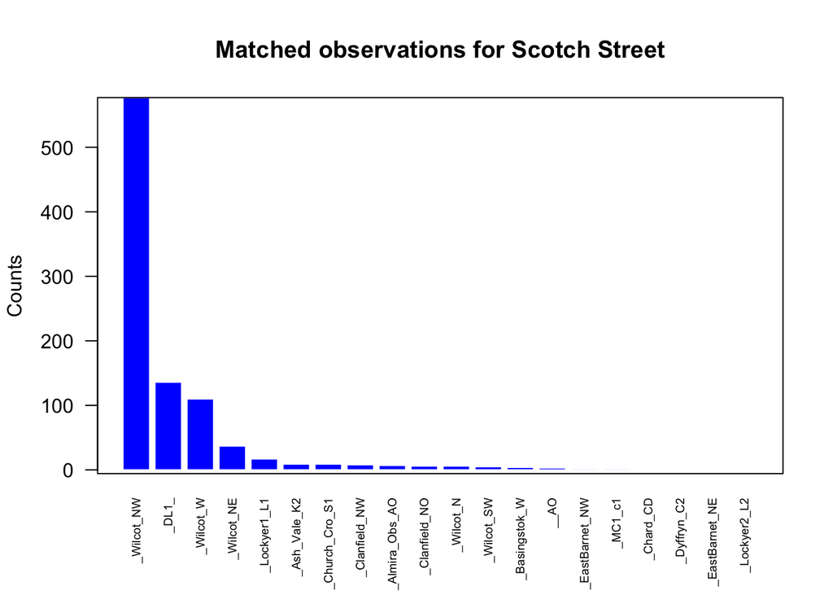

# Detailed counts (including sporadics)

| Shower | Counts |
| --- | --- |
| SPO | 1177 |
| PER | 804 |
| GEM | 298 |
| ORI | 121 |
| QUA | 112 |
| LEO | 97 |
| NTA | 76 |
| COM | 72 |
| LYR | 68 |
| STA | 68 |
| ZCS | 64 |
| XAU | 58 |
| HYD | 53 |
| DAD | 49 |
| URS | 49 |
| AGC | 48 |
| DLM | 47 |
| AUR | 45 |
| KDR | 45 |
| MPR | 42 |
| DCL | 39 |
| KUM | 39 |
| NOO | 39 |
| PSU | 38 |
| UUM | 38 |
| BPE | 37 |
| DTA | 37 |
| JZD | 37 |
| PSA | 37 |
| CVN | 36 |

[output cut: 339 more lines]